# Session 05: Measuring affective polarization

Tristan Muno

October 14, 2026

## Session 05 goals

By the end of today, you will be able to:

1. Say what a feeling thermometer measures and what it does not.
2. Reconstruct how an AP score is built in a multiparty system, and state what each step of the construction assumes.
3. Explain why the decision about who counts as a partisan changes the population an estimate refers to.
4. Judge whether a published estimate supports a comparison across countries or over time.

## Today

1. **Two parties**
   - The thermometer, and AP from one person to a country
2. **Many parties**
   - Three measures, one respondent
3. **Whose AP?**
   - The population behind the number
4. **What does the thermometer capture?**
   - Parties or people, vertical or horizontal
5. **Wrap-up**
6. **Your term paper**

# Two parties

## The thermometer

“Please rate each party on a scale from 0 to 100. Ratings above 50 mean you feel warm toward it, below 50 cold.”

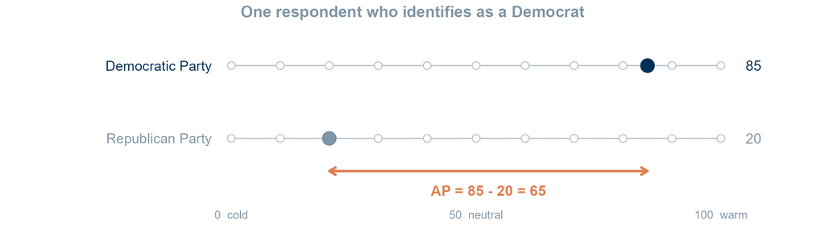

Figure 1: One fictional Democrat rates the Democratic Party at 85 and the Republican Party at 20 on the 0 to 100 feeling thermometer. Their affective polarization is the gap between the two ratings, 65 points.

$$AP_i = T_{i,\text{in}} - T_{i,\text{out}} = 85 - 20 = 65
\tag{1}$$

**Note**

**How to read it.** Take your rating of your own party and subtract your rating of the other party. The bigger the gap, the more polarized you are.

## From one person to a country

Table 1: Thermometer ratings and individual AP of six fictional partisans. Each respondent’s in-party rating minus their out-party rating.

| Respondent | Party | $T_\text{Dem}$ | $T_\text{Rep}$ | $AP_i$ |
| --- | --- | --- | --- | --- |
| 1 | Dem | 85 | 20 | 65 |
| 2 | Dem | 70 | 40 | 30 |
| 3 | Dem | 90 | 10 | 80 |
| 4 | Rep | 15 | 80 | 65 |
| 5 | Rep | 30 | 75 | 45 |
| 6 | Rep | 5 | 95 | 90 |

Average $AP_i$ over any group $g$:

$$AP_g = \frac{1}{N_g} \sum_{i \in g} AP_i
\tag{2}$$

- Democrats: $(65 + 30 + 80)/3 = 58.3$
- Republicans: $(65 + 45 + 90)/3 = 66.7$
- Sample, or country-year: $375/6 = 62.5$

**Note**

**How to read it.** Add up the AP scores of everyone in a group and divide by the number of people in it. The group can be a party, a sample, or a country in a given year.

## Who is *in*?

Equation 1 needs an in-party before it can be computed. Who decides which party is the respondent’s own?

- **Attachment**: the party they say they feel close to
- **Vote choice**: the party they voted for
- **Most liked**: the party they rate highest

Even with two parties, there is a conceptual choice before the arithmetic starts.

# Many parties

## The problem

- With many parties there is no single “other party” to subtract
- People can like **more than one** party, and form blocs (Wagner 2021)
- Dislike can grow **without** a strong in-party, for example toward a new radical party
- Parties differ in **size**

Each measure answers these questions differently.

## One respondent, four parties

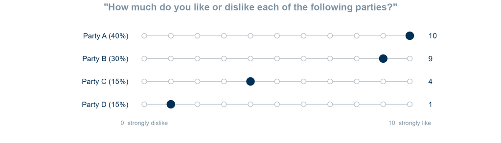

Figure 2: A fictional respondent rates four parties on the 0 to 10 like/dislike scale: A 10, B 9, C 4, D 1. Vote shares in brackets. The same ratings feed every measure on the following slides.

- The respondent feels close to Party A
- Vote shares follow Wagner (2021), Table 1

## Reiljan: the AP index

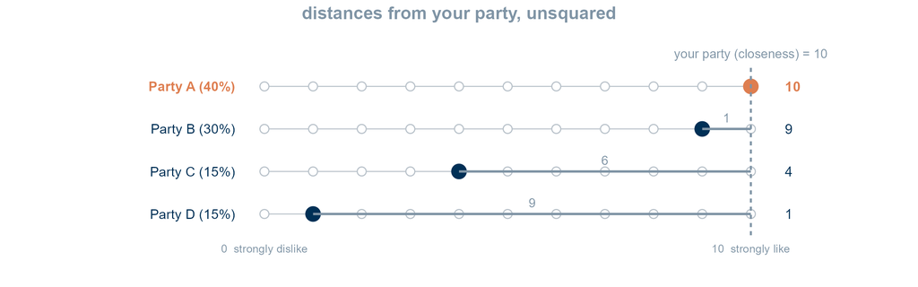

Figure 3: Distances from the respondent’s own party, Party A, to each other party, unsquared. *Source:* adapted from Reiljan (2020).

Unweighted: $10 - \frac{9+4+1}{3} = 10 - 4.67 = \mathbf{5.33}$

$$AP_n = \sum_{m \neq n} (\text{Like}_n - \text{Like}_m) \frac{V_m}{1 - V_n}
\tag{3}$$

$$API = \sum_{n} AP_n \times V_n
\tag{4}$$

$n$ is the in-party, $m$ an out-party, $V$ a vote share.

- In-group: the party you **feel close to**
- Only **partisans** get a score
- One in-group: B counts as an out-party

**Note**

**How to read it.** For the supporters of each party, take how much more they like their own party than each rival, and let bigger rivals count more. Then average these party scores, letting bigger parties count more.

## Wagner: mean distance

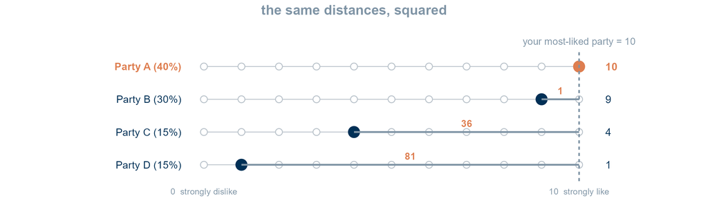

Figure 4: The same distances from the most-liked party, now squared. *Source:* adapted from Wagner (2021).

Unweighted: $\sqrt{\frac{1+36+81}{3}} = \sqrt{39.3} = \mathbf{6.27}$

$$\text{Distance}_i = \sqrt{\frac{\sum_{p} (\text{like}_{ip} - \text{like}_{\max,i})^2}{n_p}}
\tag{5}$$

$$\text{Distance}^{w}_i = \sqrt{\sum_{p} v_p (\text{like}_{ip} - \text{like}_{\max,i})^2}
\tag{6}$$

$n_p$ counts the parties other than the most-liked one, $v_p$ is a vote share.

- In-group: the party you **rate highest**
- **Anyone** with two ratings gets a score
- Squaring stresses the most disliked party

**Note**

**How to read it.** How far each other party falls below your favourite, on average, where large gaps count extra because they are squared. The weighted version lets bigger parties count more.

## Wagner: spread of scores

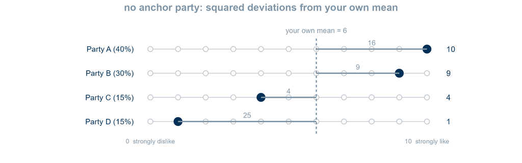

Figure 5: Squared deviations of each rating from the respondent’s own mean rating, 6. No party serves as the anchor. *Source:* adapted from Wagner (2021).

Unweighted: $\sqrt{\frac{16+9+4+25}{4}} = \sqrt{13.5} = \mathbf{3.67}$

$$\text{Spread}_i = \sqrt{\frac{\sum_{p} (\text{like}_{ip} - \overline{\text{like}}_i)^2}{n_p}}
\tag{7}$$

$$\text{Spread}^{w}_i = \sqrt{\sum_{p} v_p (\text{like}_{ip} - \overline{\text{like}}_i)^2}
\tag{8}$$

$$\overline{\text{like}}_i = \sum_{p} v_p \, \text{like}_{ip}
\tag{9}$$

- **No in-group** at all
- **Everyone** with two ratings gets a score
- Allows **blocs**: two liked parties against two disliked ones

**Note**

**How to read it.** How far your ratings scatter around your own average rating, with no party treated as yours. The weighted version lets bigger parties count more, both in the average and in the scatter.

## Why weight?

The scale shows every party as an equal line, but parties are **not** equal in size.

- **For**: disliking a 40% party says more about a system than disliking a 3% one (Wagner 2021)
- **For**: surveys list different numbers of small parties, and weights damp that
- **Against**: more choices to make and report
- **Against**: AP changes when vote shares change, even if no feeling changes (Reiljan 2020)

**Note**

**Weighting answers a different question.** Unweighted: how polarized is this person’s view of all parties? Weighted: how polarized is this person’s view of the parties that matter for the system?

## Same ratings, three scores

Table 2: Three AP measures computed from the same four ratings (A 10, B 9, C 4, D 1), with and without vote-share weights. Each measure makes its own assumption about who the in-group is and who gets a score.

| Measure | In-group | Who gets a score | Blocs? | Unweighted | Weighted |
| --- | --- | --- | --- | --- | --- |
| API (Reiljan 2020) | Declared closeness | Partisans | No | 5.33 | 4.25 |
| Distance (Wagner 2021) | Highest rating | Anyone with 2+ ratings | No | 6.27 | 5.45 |
| Spread (Wagner 2021) | None | Anyone with 2+ ratings | Yes | 3.67 | 3.37 |

**Important**

**A number without its measure means nothing.** Always state which measure, weighted or not, and who was included.

## Does the choice matter?

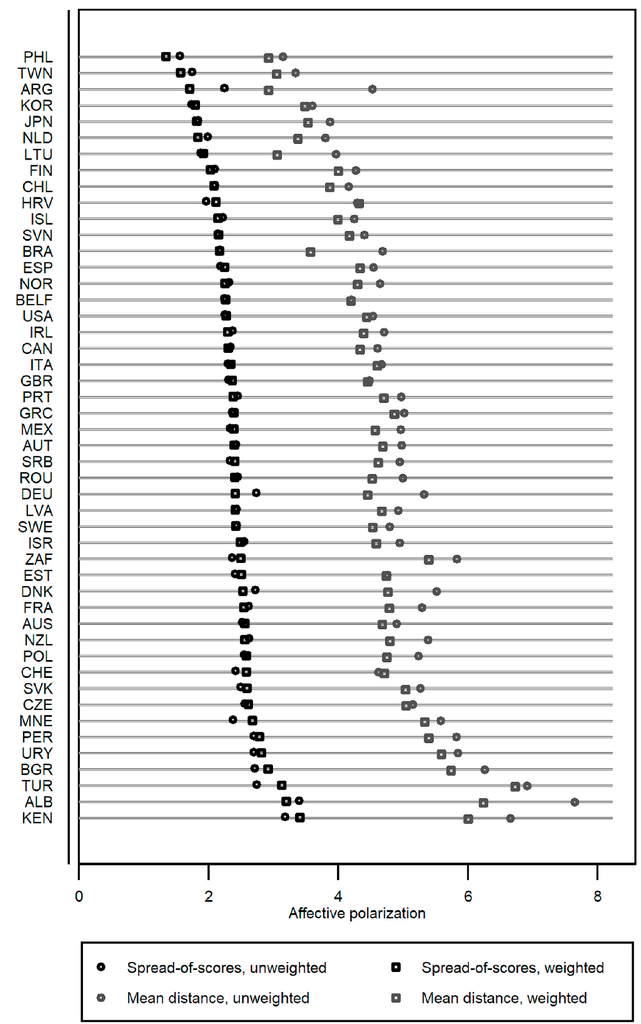

Figure 6: Mean affective polarization by country in CSES modules 1 to 5, on four measures: spread and mean distance, each unweighted and weighted. Levels differ by measure, the country ranking hardly does. *Source:* Wagner (2021), Figure 1.

- Levels differ: distance always sits above spread
- Rankings barely move: the measures correlate at about .9
- Few voters have **one** strong in-party
- The US is average in this comparison

Check the robustness of your result across measures, and report it.

# Whose AP?

## Population of inference

Do we want the AP of

- **partisans** (attached to a party)?
- **voters** (voted for one)?
- partisans **and** voters?
- the **whole** sample?
- The answer fixes how the in-group is coded
- And it fixes **whose** AP the estimate describes
- API: partisans only. Distance and spread: anyone who rates two parties.

## Who is in the sample?

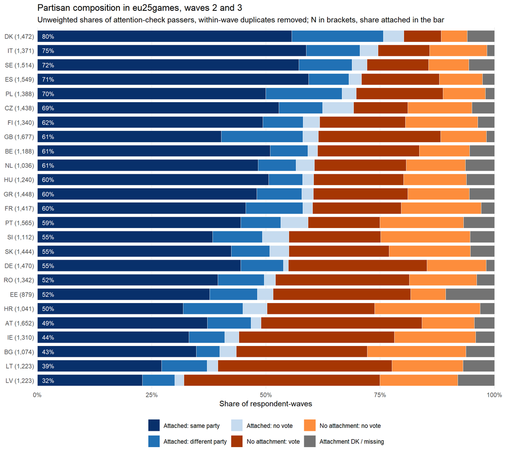

Figure 7: Partisan composition of the eu25games survey, waves 2 and 3, by country. Blue segments are respondents attached to a party, red and orange are respondents without attachment, split by whether they report a vote. The attached share, printed in each bar, ranges from 80% in Denmark to 32% in Latvia. *Data:* eu25games, doi.org/10.5281/zenodo.21294635, see Hahm et al. (2024). Unweighted shares of attention-check passers.

## Say whose AP

**Important**

**Be clear whose AP you study.** Your in-group rule decides who gets a score, and so which population your estimate describes. In a comparison across countries or over time, report the sample composition next to the estimate.

- A partisans-only estimate in Latvia describes about a third of respondents, in Denmark about four in five
- A difference between them may be a difference in **who was counted**

# What does the thermometer capture?

## Back to the definition

> “the tendency of people identifying as [partisans] to view opposing partisans negatively and copartisans positively” (Iyengar and Westwood 2015, 691)
- The definition is about **people**: fellow citizens who support a party
- The *standard* thermometer asks about **parties**
- Thermometers can also target partisans, for example “Democratic Party voters” (Druckman and Levendusky 2019)
- Whom do respondents picture: the neighbour, or the party leader? (Druckman and Levendusky 2019)

## D&L (2019): design

1. **Do the measures agree?** Thermometer, trait ratings, trust, social distance
2. **Whom do people picture?** Random assignment of the target:
   - “the Democratic (Republican) Party”
   - “Democratic (Republican) Party **voters**”
   - “Democratic (Republican) Party **candidates and elected officials**”

US online survey, 2017, partisans and leaners, N about 2,200

## D&L (2019): results

Table 3: Mean out-party feeling thermometer rating by randomly assigned target, US partisans and leaners, 2017. Ratings of “the party” match those of its elites, not those of its voters. *Source:* Druckman and Levendusky (2019), Table 2.

| Target of the out-party thermometer | Mean rating |
| --- | --- |
| Party voters | 28.8 |
| Candidates and elected officials | 24.7 |
| The party | 23.4 |

- “The party” means its **elites**
- People dislike out-party voters, and out-party elites even more
- Thermometer, traits and trust correlate well, social distance much less

## Vertical and horizontal

- **Vertical AP**: affect toward parties and their elites
- **Horizontal AP**: affect toward ordinary citizens who support them (Areal and Harteveld 2024)
- The definition is horizontal
- A party thermometer is vertical, a thermometer of party voters is horizontal
- They are related, but not the same thing

**Important**

**Be clear which AP dimension your measure captures.** A party thermometer speaks to feelings about parties and elites. A claim about citizens disliking each other needs a measure that targets citizens.

## Where do our measures sit?

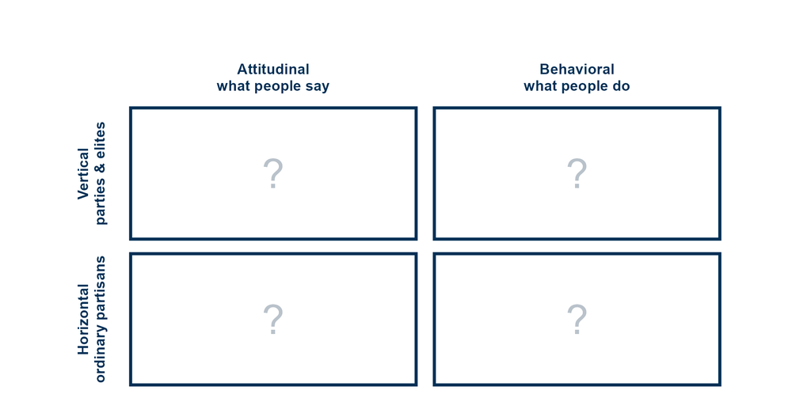

Figure 8: Two dimensions of measuring affective polarization: the target, parties and elites (vertical) or ordinary partisans (horizontal), and the mode, what people say (attitudinal) or what people do (behavioral). The cells are left open for the discussion.

Place today’s measures and last week’s in the grid.

## The grid filled in

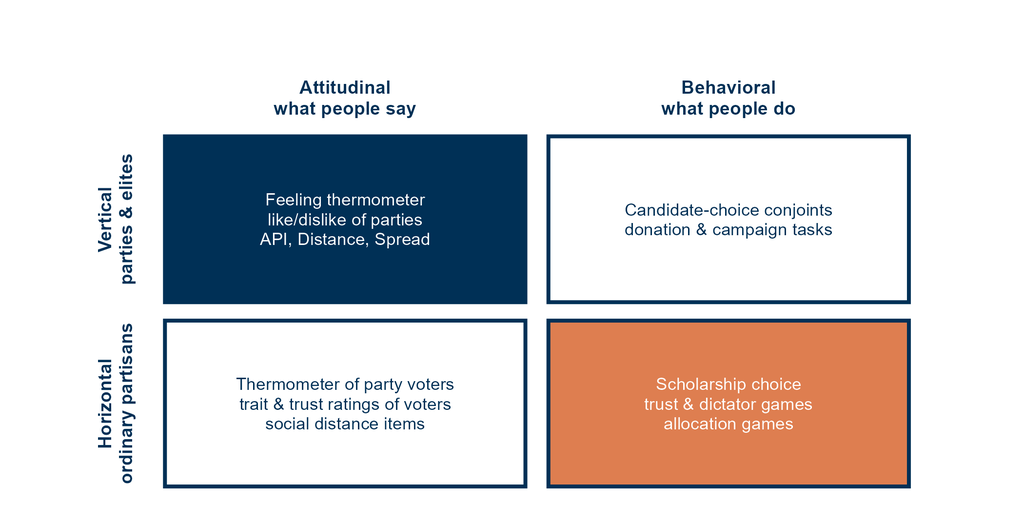

Figure 9: The same grid with typical measures in each cell. Today’s thermometer measures sit in the vertical attitudinal cell, where nearly all comparative work lies. Next session moves to the horizontal behavioral cell.

Today: the **left column**. Next week: the **bottom right**.

# Wrap-up

## Recap: takeaways

- In two-party systems, AP is the in-party minus the out-party rating, averaged over any group
- In multiparty systems, API, distance and spread give different numbers from the same ratings
- Each measure assumes who the in-group is, and who gets a score
- That choice fixes whose AP an estimate describes
- Party thermometers capture **vertical** AP, mostly feelings about elites

## Recap: learning goals

**Goal 1. What a thermometer measures**

- Warmth toward parties, which respondents read as their elites, not toward fellow partisans

**Goal 2. Building an AP score with many parties**

- Pick an in-group rule (closeness, top rating, none), a distance (plain or squared), and weights (or none)

**Goal 3. Who counts as a partisan**

- The in-group rule decides who gets a score, so it decides whose AP you estimate

**Goal 4. Comparisons across countries and time**

- Only with the same measure, and with the sample composition reported

# Your term paper

## Start now

- Begin thinking about what interests you, and look for data and papers
- A good strategy: take an **existing empirical paper** that interests you, and **tweak it**
  - another country, period, measure, population or outcome
- That is completely fine, and it is how much published research starts

## What I expect

A paper as close to **publication-ready** as possible. Above all, I care about the **logic of the argument**.

The magic five:

1. Introduction
2. Theory
3. Research design
4. Empirical analysis
5. Conclusion
- The whole paper is **one large argument**
- Every section, and every paragraph, is a **smaller argument** that serves it

## Sections as arguments (1)

**Introduction**: why your research question is interesting (puzzling), or important, or both. Then a short overview of all other sections.

**Theory**: why, based on the literature and your own reasoning, things should be the way you expect. Ideally: why your hypotheses follow logically from the state of research.

**Research design**: why your data, measurement and analysis are well suited to the question and the hypotheses. Be open about what the data can and cannot do. Do not overclaim.

## Sections as arguments (2)

**Empirical analysis**: why the patterns in your results support, or contradict, your hypotheses and interpretations. Again, be honest about what the method can and cannot say.

**Conclusion**: a recap of the whole chain of argument, and why your study contributes to the literature.

**Note**

**A concrete grading scheme follows later in the course.** It will assess all five parts of this scheme.

## Next session

- **Session 06: Beyond the thermometer: behavioral measures**
- Today we stayed in the left column. Next we move to the bottom right.
- Core reading: Hahm et al. (2024) and Stoetzer et al. (2023)

## References

Areal, João, and E. Harteveld. 2024. “Vertical Vs Horizontal Affective Polarization: Disentangling Feelings Towards Elites and Voters.” *Electoral Studies* 90. https://doi.org/10.1016/j.electstud.2024.102814.

Druckman, James, and Matthew Levendusky. 2019. “What Do We Measure When We Measure Affective Polarization?” *Public Opinion Quarterly* 83 (1): 114–22. https://doi.org/10.1093/poq/nfz003.

Hahm, Hyeonho, David Hilpert, and Thomas König. 2024. “Divided We Unite: The Nature of Partyism and the Role of Coalition Partnership in Europe.” *American Political Science Review* 118 (1): 69–87. https://doi.org/10.1017/S0003055423000266.

Iyengar, Shanto, and Sean J. Westwood. 2015. “Fear and Loathing Across Party Lines: New Evidence on Group Polarization.” *American Journal of Political Science* 59 (3): 690–707. https://doi.org/10.1111/ajps.12152.

Reiljan, Andres. 2020. “‘Fear and Loathing Across Party Lines’(also) in Europe: Affective Polarisation in European Party Systems.” *European Journal of Political Research* 59 (2): 376–96. https://doi.org/10.1111/1475-6765.12351.

Stoetzer, Lukas F., Simon Munzert, Will Lowe, et al. 2023. “Affective Partisan Polarization and Moral Dilemmas During the COVID-19 Pandemic.” *Political Science Research and Methods* 11 (2): 429–36. https://doi.org/10.1017/psrm.2022.13.

Wagner, Markus. 2021. “Affective Polarization in Multiparty Systems.” *Electoral Studies* 69: 102199. https://doi.org/10.1016/j.electstud.2020.102199.